```python
#!git clone https://github.com/hussnain-imtiaz/POI_Analysis.git
#!mv /content/POI_Analysis/final_project /content
#!mv /content/POI_Analysis/tools /content
```

[output not shown]

# Installing all the required tools:

Any missing tool(s) can be installed by using pip command.

```python
#!pip install pycaret
#!pip install numpy
#!pip install pandas matplotlib seaborn sklearn
```

# 2. Getting the Tools Ready:

```python
import pandas as pd
import sys
import numpy as np
import pickle
from pycaret.classification import *
import seaborn as sns
import matplotlib.pyplot as plt

from final_project.tester import dump_classifier_and_data
from tools.feature_format import featureFormat, targetFeatureSplit


# Provided to give you a starting point. Try a variety of classifiers.
from sklearn.naive_bayes import GaussianNB
from sklearn.svm import SVC
from sklearn.linear_model import LogisticRegression
from sklearn.ensemble import RandomForestClassifier
from final_project.tester import test_classifier
from sklearn.ensemble import GradientBoostingClassifier
from sklearn.tree import DecisionTreeClassifier
```

# 3. Loading the data:

```python
### Load the dictionary containing the dataset
with open("/content/final_project/final_project_dataset.pkl", "rb") as data_file:
    data_dict = pickle.load(data_file)
```

# 4. Getting the data Ready:

In the intial run we will take all the available features and then based on analysis report we will select the best ones.

```python
### Task 1: Select what features you'll use.
### features_list is a list of strings, each of which is a feature name.
### The first feature must be "poi".
features_list = ['poi', 'salary', 'deferral_payments', 'total_payments', 'loan_advances',
                 'bonus', 'restricted_stock_deferred', 'deferred_income',
                 'total_stock_value', 'expenses', 'exercised_stock_options',
                 'other', 'long_term_incentive', 'restricted_stock', 'director_fees',
                 'to_messages', 'from_poi_to_this_person', 'from_messages',
                 'from_this_person_to_poi', 'shared_receipt_with_poi']
```

```python
### Store to my_dataset for easy export below.
my_dataset = data_dict

### Extract features and labels from dataset for local testing
data = featureFormat(my_dataset, features_list, sort_keys = True)

### converting the data to df for some analysis and exploration
my_data = pd.DataFrame(data, columns=features_list)
my_data.head()
```

|  | poi | salary | deferral_payments | total_payments | loan_advances | bonus | restricted_stock_deferred | deferred_income | total_stock_value | expenses | exercised_stock_options | other | long_term_incentive | restricted_stock | director_fees | to_messages | from_poi_to_this_person | from_messages | from_this_person_to_poi | shared_receipt_with_poi |
| --- | --- | --- | --- | --- | --- | --- | --- | --- | --- | --- | --- | --- | --- | --- | --- | --- | --- | --- | --- | --- |
| 0 | 0.0 | 201955.0 | 2869717.0 | 4484442.0 | 0.0 | 4175000.0 | -126027.0 | -3081055.0 | 1729541.0 | 13868.0 | 1729541.0 | 152.0 | 304805.0 | 126027.0 | 0.0 | 2902.0 | 47.0 | 2195.0 | 65.0 | 1407.0 |
| 1 | 0.0 | 0.0 | 178980.0 | 182466.0 | 0.0 | 0.0 | 0.0 | 0.0 | 257817.0 | 3486.0 | 257817.0 | 0.0 | 0.0 | 0.0 | 0.0 | 0.0 | 0.0 | 0.0 | 0.0 | 0.0 |
| 2 | 0.0 | 477.0 | 0.0 | 916197.0 | 0.0 | 0.0 | -560222.0 | -5104.0 | 5243487.0 | 56301.0 | 4046157.0 | 864523.0 | 0.0 | 1757552.0 | 0.0 | 566.0 | 39.0 | 29.0 | 0.0 | 465.0 |
| 3 | 0.0 | 267102.0 | 1295738.0 | 5634343.0 | 0.0 | 1200000.0 | 0.0 | -1386055.0 | 10623258.0 | 11200.0 | 6680544.0 | 2660303.0 | 1586055.0 | 3942714.0 | 0.0 | 0.0 | 0.0 | 0.0 | 0.0 | 0.0 |
| 4 | 0.0 | 239671.0 | 260455.0 | 827696.0 | 0.0 | 400000.0 | -82782.0 | -201641.0 | 63014.0 | 129142.0 | 0.0 | 69.0 | 0.0 | 145796.0 | 0.0 | 0.0 | 0.0 | 0.0 | 0.0 | 0.0 |

### i. Exploratory Data Analysis

```python
# inspect info
my_data.info()
```

```
<class 'pandas.core.frame.DataFrame'>
RangeIndex: 145 entries, 0 to 144
Data columns (total 20 columns):
 #   Column                     Non-Null Count  Dtype
---  ------                     --------------  -----
 0   poi                        145 non-null    float64
 1   salary                     145 non-null    float64
 2   deferral_payments          145 non-null    float64
 3   total_payments             145 non-null    float64
 4   loan_advances              145 non-null    float64
 5   bonus                      145 non-null    float64
 6   restricted_stock_deferred  145 non-null    float64
 7   deferred_income            145 non-null    float64
 8   total_stock_value          145 non-null    float64
 9   expenses                   145 non-null    float64
 10  exercised_stock_options    145 non-null    float64
 11  other                      145 non-null    float64
 12  long_term_incentive        145 non-null    float64
 13  restricted_stock           145 non-null    float64
 14  director_fees              145 non-null    float64
 15  to_messages                145 non-null    float64
 16  from_poi_to_this_person    145 non-null    float64
 17  from_messages              145 non-null    float64
 18  from_this_person_to_poi    145 non-null    float64
 19  shared_receipt_with_poi    145 non-null    float64
dtypes: float64(20)
memory usage: 22.8 KB
```

**We see no missing values because they were imputed with '0'. But it doesnt mean that there is no missing values. We will find their % later.**

#### (A). Total Number of data points and their distribution across different classes (poi/non-poi)

```python
### how many data points we have?
len(my_data)
```

```
145
```

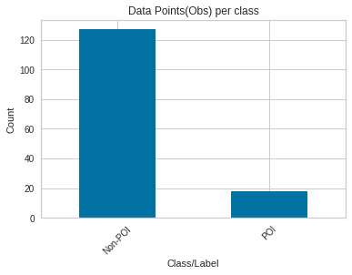

```python
### distribution across different classes
plt.title('Data Points(Obs) per class')
plt.xlabel('Class/Label')
plt.ylabel('Count')
my_data['poi'].value_counts().plot.bar()
plt.xticks([0, 1], labels=['Non-POI', 'POI'], rotation=45)
plt.show()
```

#### (B). Looking up for the missing values in availble features and filtereing the ones with less than 50% missing values.

```python
### find how many values are missing in each column
filtered_features_missing = []
missing_count = []
for col in features_list[1:]:
  missing_vals = len(my_data[col][np.where(my_data[col]==0)[0]])
  missing_count.append(missing_vals)
  total_vals = len(my_data[col])
  ptc_missing = missing_vals / total_vals
  if ptc_missing < 0.5:
    filtered_features_missing.append(col)
  print(f'{col} = {ptc_missing:.2f}%')
```

```
salary = 0.34%
deferral_payments = 0.73%
total_payments = 0.14%
loan_advances = 0.97%
bonus = 0.43%
restricted_stock_deferred = 0.88%
deferred_income = 0.66%
total_stock_value = 0.13%
expenses = 0.34%
exercised_stock_options = 0.30%
other = 0.36%
long_term_incentive = 0.54%
restricted_stock = 0.24%
director_fees = 0.88%
to_messages = 0.41%
from_poi_to_this_person = 0.49%
from_messages = 0.41%
from_this_person_to_poi = 0.54%
shared_receipt_with_poi = 0.41%
```

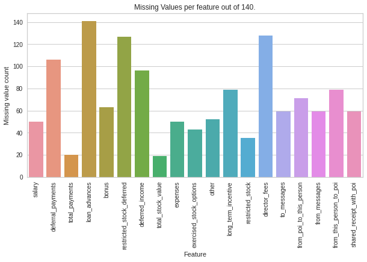

```python
### Visualizing the missing values (by count)
plt.figure(figsize=(10,5))
sns.barplot(x=features_list[1:], y=missing_count)
plt.xticks(rotation=90)
plt.title('Missing Values per feature out of 140.')
plt.xlabel('Feature')
plt.ylabel('Missing value count')
plt.show()
```

```python
### some filtered features those are having less than 50% missing values
filtered_features_missing
```

```
['salary',
 'total_payments',
 'bonus',
 'total_stock_value',
 'expenses',
 'exercised_stock_options',
 'other',
 'restricted_stock',
 'to_messages',
 'from_poi_to_this_person',
 'from_messages',
 'shared_receipt_with_poi']
```

#### (C). Finding the correlation between dependent and independant variable

```python
my_data.corr().iloc[0]
```

```
poi                          1.000000
salary                      -0.001058
deferral_payments           -0.040847
total_payments               0.049386
loan_advances                0.131550
bonus                        0.023341
restricted_stock_deferred   -0.005402
deferred_income             -0.039149
total_stock_value            0.034064
expenses                    -0.009886
exercised_stock_options      0.039922
other                        0.021832
long_term_incentive          0.012467
restricted_stock             0.014801
director_fees               -0.061847
to_messages                  0.110006
from_poi_to_this_person      0.191549
from_messages               -0.033302
from_this_person_to_poi      0.130319
shared_receipt_with_poi      0.242105
Name: poi, dtype: float64
```

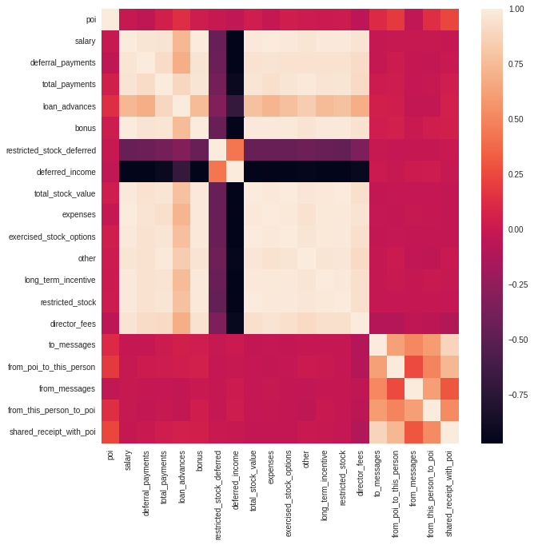

```python
### find the correlation in all_features
plt.figure(figsize=(10, 10))
sns.heatmap(my_data.corr());
```

**There is no super corelation.**

#### (D). Is the Data Balanced?

```python
pd.DataFrame(data_dict).T['poi'].value_counts()
```

```
False    128
True      18
Name: poi, dtype: int64
```

**Data is very much imbalanced and more biased to class 0.**

### ii. Data Preparation

We will prepare the data for better analysis and modeling. We will

1. Remove the outliers
2. Create new feature(s)
3. Select higly correlated features

**Inspecting with box plot**

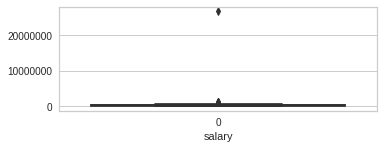

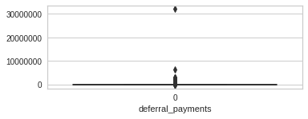

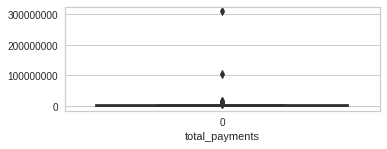

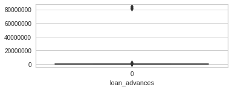

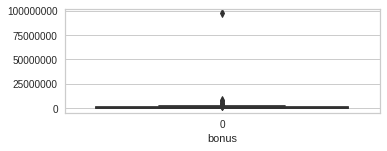

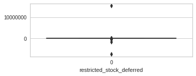

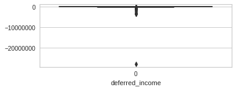

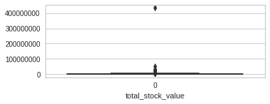

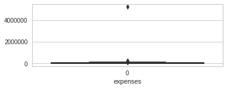

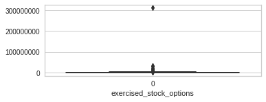

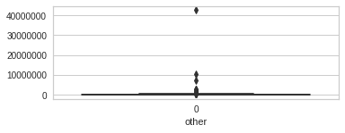

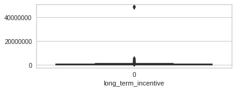

[7 more figures not shown]

```python
### Task 2: Remove outliers

for i in range(1, len(features_list)):
  plt.figure(figsize = (10,20))
  plt.subplot(10, 2, i)
  sns.boxplot(data=my_data[features_list[i]])
  plt.ticklabel_format(style='plain', axis='y')
  plt.xlabel(features_list[i])
  plt.tight_layout()
```

**Using IQR**

```python
q1 = my_data.quantile(0.25)
q3 = my_data.quantile(0.75)
iqr = q3 - q1
```

```python
iqr
```

```
poi                                0.0
salary                        271442.0
deferral_payments              10259.0
total_payments               1877096.0
loan_advances                      0.0
bonus                         800000.0
restricted_stock_deferred          0.0
deferred_income                38346.0
total_stock_value            2080344.0
expenses                       53947.0
exercised_stock_options      1729541.0
other                         150656.0
long_term_incentive           375304.0
restricted_stock              820604.0
director_fees                      0.0
to_messages                     1607.0
from_poi_to_this_person           41.0
from_messages                     52.0
from_this_person_to_poi           14.0
shared_receipt_with_poi          900.0
dtype: float64
```

```python
(my_data < (q1 - 1.5 * iqr)) | (my_data > (q3 + 1.5 * iqr))
```

|  | poi | salary | deferral_payments | total_payments | loan_advances | bonus | restricted_stock_deferred | deferred_income | total_stock_value | expenses | exercised_stock_options | other | long_term_incentive | restricted_stock | director_fees | to_messages | from_poi_to_this_person | from_messages | from_this_person_to_poi | shared_receipt_with_poi |
| --- | --- | --- | --- | --- | --- | --- | --- | --- | --- | --- | --- | --- | --- | --- | --- | --- | --- | --- | --- | --- |
| 0 | False | False | True | False | False | True | True | True | False | False | False | False | False | False | False | False | False | True | True | False |
| 1 | False | False | True | False | False | False | False | False | False | False | False | False | False | False | False | False | False | False | False | False |
| 2 | False | False | False | False | False | False | True | False | False | False | False | True | False | False | False | False | False | False | False | False |
| 3 | False | False | True | True | False | False | False | True | True | False | True | True | True | True | False | False | False | False | False | False |
| 4 | False | False | True | False | False | False | True | True | False | False | False | False | False | False | False | False | False | False | False | False |
| 5 | False | False | True | False | False | False | False | False | False | False | False | False | False | False | False | False | False | False | False | False |
| 6 | False | False | False | False | False | False | False | False | False | False | False | False | False | False | False | True | True | True | True | True |
| 7 | True | False | True | True | False | True | False | True | False | False | False | False | False | False | False | True | True | True | True | True |
| 8 | False | False | True | False | False | False | True | False | False | False | False | False | False | False | True | False | False | False | False | False |
| 9 | False | False | False | False | False | False | False | False | False | False | False | False | False | False | False | False | False | False | False | False |
| 10 | False | False | False | False | False | False | False | True | False | False | False | True | False | False | False | False | False | False | False | False |
| 11 | False | False | False | True | False | False | True | False | False | False | False | False | False | True | True | False | False | False | False | False |
| 12 | False | False | False | False | False | False | False | False | False | False | False | True | False | False | False | False | False | False | False | False |
| 13 | False | False | False | False | False | False | False | False | False | False | False | False | False | False | False | False | False | False | False | True |
| 14 | False | False | False | False | False | False | False | True | False | False | False | False | False | False | True | False | False | False | False | False |
| 15 | True | False | False | False | False | False | False | False | False | False | False | False | True | False | False | False | True | False | False | False |
| 16 | False | False | False | False | False | False | False | False | False | False | False | False | False | False | False | False | False | False | False | False |
| 17 | False | False | False | False | False | False | False | False | False | False | False | False | False | False | False | False | False | False | False | False |
| 18 | False | False | False | False | False | False | False | False | False | False | False | False | False | False | False | False | False | False | False | False |
| 19 | False | False | True | False | False | False | False | True | False | False | False | True | False | False | False | False | True | True | True | True |
| 20 | True | False | False | False | False | False | False | True | False | False | False | False | False | False | False | False | True | True | False | False |
| 21 | False | False | False | False | False | False | True | True | False | False | False | False | False | False | False | False | False | False | False | False |
| 22 | True | False | False | False | False | False | False | True | False | False | False | False | False | True | False | False | False | False | False | False |
| 23 | False | False | False | False | False | False | True | True | False | False | False | False | False | False | True | False | False | False | False | False |
| 24 | False | False | False | False | False | False | False | False | True | False | True | False | False | False | False | False | False | False | False | False |
| 25 | False | False | False | False | False | False | True | False | False | False | False | False | False | False | False | False | False | False | False | False |
| 26 | True | False | True | False | False | False | False | True | False | False | False | False | False | False | False | False | True | False | False | False |
| 27 | False | False | False | False | False | False | False | False | False | False | False | False | False | False | False | False | False | False | False | False |
| 28 | False | False | False | False | False | False | False | False | False | False | False | False | False | False | False | False | False | False | False | False |
| 29 | False | False | False | False | False | False | False | False | False | False | False | False | False | False | False | False | False | False | False | False |

[output cut: 115 more lines]

`True` in the data frame above represents the presence of outliers.

```python
((my_data > (q3 + 1.5 * iqr)) | (my_data < (q1 - 1.5 * iqr))).any(axis=1)
```

```
0       True
1       True
2       True
3       True
4       True
5       True
6       True
7       True
8       True
9      False
10      True
11      True
12      True
13      True
14      True
```

[output cut: 131 more lines]

```python
### removal of oultliers based on iqr
my_data_outliers_rm = my_data[((my_data > (q3 + 1.5 * iqr)) | (my_data < (q1 - 1.5 * iqr))).any(axis=1)]
```

```python
my_data_outliers_rm.reset_index(inplace=True, drop=True)
```

```python
my_data_outliers_rm
```

|  | poi | salary | deferral_payments | total_payments | loan_advances | bonus | restricted_stock_deferred | deferred_income | total_stock_value | expenses | exercised_stock_options | other | long_term_incentive | restricted_stock | director_fees | to_messages | from_poi_to_this_person | from_messages | from_this_person_to_poi | shared_receipt_with_poi |
| --- | --- | --- | --- | --- | --- | --- | --- | --- | --- | --- | --- | --- | --- | --- | --- | --- | --- | --- | --- | --- |
| 0 | 0.0 | 201955.0 | 2869717.0 | 4484442.0 | 0.0 | 4175000.0 | -126027.0 | -3081055.0 | 1729541.0 | 13868.0 | 1729541.0 | 152.0 | 304805.0 | 126027.0 | 0.0 | 2902.0 | 47.0 | 2195.0 | 65.0 | 1407.0 |
| 1 | 0.0 | 0.0 | 178980.0 | 182466.0 | 0.0 | 0.0 | 0.0 | 0.0 | 257817.0 | 3486.0 | 257817.0 | 0.0 | 0.0 | 0.0 | 0.0 | 0.0 | 0.0 | 0.0 | 0.0 | 0.0 |
| 2 | 0.0 | 477.0 | 0.0 | 916197.0 | 0.0 | 0.0 | -560222.0 | -5104.0 | 5243487.0 | 56301.0 | 4046157.0 | 864523.0 | 0.0 | 1757552.0 | 0.0 | 566.0 | 39.0 | 29.0 | 0.0 | 465.0 |
| 3 | 0.0 | 267102.0 | 1295738.0 | 5634343.0 | 0.0 | 1200000.0 | 0.0 | -1386055.0 | 10623258.0 | 11200.0 | 6680544.0 | 2660303.0 | 1586055.0 | 3942714.0 | 0.0 | 0.0 | 0.0 | 0.0 | 0.0 | 0.0 |
| 4 | 0.0 | 239671.0 | 260455.0 | 827696.0 | 0.0 | 400000.0 | -82782.0 | -201641.0 | 63014.0 | 129142.0 | 0.0 | 69.0 | 0.0 | 145796.0 | 0.0 | 0.0 | 0.0 | 0.0 | 0.0 | 0.0 |
| 5 | 0.0 | 80818.0 | 684694.0 | 860136.0 | 0.0 | 0.0 | 0.0 | 0.0 | 1599641.0 | 0.0 | 1599641.0 | 874.0 | 93750.0 | 0.0 | 0.0 | 0.0 | 0.0 | 0.0 | 0.0 | 0.0 |
| 6 | 0.0 | 231330.0 | 0.0 | 969068.0 | 0.0 | 700000.0 | 0.0 | 0.0 | 126027.0 | 37172.0 | 0.0 | 566.0 | 0.0 | 126027.0 | 0.0 | 7315.0 | 144.0 | 4343.0 | 386.0 | 2639.0 |
| 7 | 1.0 | 213999.0 | 2144013.0 | 5501630.0 | 0.0 | 5249999.0 | 0.0 | -2334434.0 | 1110705.0 | 17355.0 | 953136.0 | 210698.0 | 0.0 | 157569.0 | 0.0 | 7991.0 | 228.0 | 484.0 | 108.0 | 5521.0 |
| 8 | 0.0 | 0.0 | -102500.0 | 102500.0 | 0.0 | 0.0 | 44093.0 | 0.0 | -44093.0 | 0.0 | 3285.0 | 0.0 | 0.0 | 0.0 | 3285.0 | 0.0 | 0.0 | 0.0 | 0.0 | 0.0 |
| 9 | 0.0 | 187922.0 | 0.0 | 618850.0 | 0.0 | 250000.0 | 0.0 | -485813.0 | 659249.0 | 59175.0 | 0.0 | 427316.0 | 180250.0 | 659249.0 | 0.0 | 383.0 | 4.0 | 59.0 | 0.0 | 233.0 |
| 10 | 0.0 | 0.0 | 0.0 | 15456290.0 | 0.0 | 0.0 | 15456290.0 | 0.0 | 0.0 | 0.0 | 2604490.0 | 137864.0 | 0.0 | -2604490.0 | 137864.0 | 523.0 | 0.0 | 29.0 | 1.0 | 463.0 |
| 11 | 0.0 | 213625.0 | 0.0 | 2047593.0 | 0.0 | 1000000.0 | 0.0 | 0.0 | 1843816.0 | 38559.0 | 1465734.0 | 425688.0 | 369721.0 | 378082.0 | 0.0 | 1607.0 | 23.0 | 40.0 | 8.0 | 1336.0 |
| 12 | 0.0 | 248546.0 | 0.0 | 2014835.0 | 0.0 | 850000.0 | 0.0 | 0.0 | 954354.0 | 84208.0 | 765313.0 | 272.0 | 831809.0 | 189041.0 | 0.0 | 2475.0 | 25.0 | 14.0 | 2.0 | 2326.0 |
| 13 | 0.0 | 0.0 | 0.0 | 1279.0 | 0.0 | 0.0 | 0.0 | -113784.0 | 0.0 | 1279.0 | 0.0 | 0.0 | 0.0 | 0.0 | 113784.0 | 0.0 | 0.0 | 0.0 | 0.0 | 0.0 |
| 14 | 1.0 | 278601.0 | 0.0 | 2669589.0 | 0.0 | 1350000.0 | 0.0 | -833.0 | 252055.0 | 65907.0 | 0.0 | 1621.0 | 974293.0 | 252055.0 | 0.0 | 1858.0 | 140.0 | 27.0 | 15.0 | 1593.0 |
| 15 | 0.0 | 330546.0 | 649584.0 | 2355702.0 | 0.0 | 900000.0 | 0.0 | -694862.0 | 3444470.0 | 0.0 | 2542813.0 | 400572.0 | 769862.0 | 901657.0 | 0.0 | 3523.0 | 156.0 | 1053.0 | 71.0 | 2333.0 |
| 16 | 1.0 | 240189.0 | 0.0 | 1639297.0 | 0.0 | 1250000.0 | 0.0 | -262500.0 | 126027.0 | 35818.0 | 0.0 | 486.0 | 375304.0 | 126027.0 | 0.0 | 2598.0 | 199.0 | 144.0 | 25.0 | 2188.0 |
| 17 | 0.0 | 261809.0 | 0.0 | 477557.0 | 0.0 | 300000.0 | -307301.0 | -159792.0 | 0.0 | 0.0 | 0.0 | 540.0 | 75000.0 | 307301.0 | 0.0 | 312.0 | 29.0 | 15.0 | 7.0 | 196.0 |
| 18 | 1.0 | 415189.0 | 0.0 | 1868758.0 | 0.0 | 1000000.0 | 0.0 | -235000.0 | 2502063.0 | 30674.0 | 0.0 | 307895.0 | 350000.0 | 2502063.0 | 0.0 | 1892.0 | 58.0 | 49.0 | 12.0 | 1585.0 |
| 19 | 0.0 | 0.0 | 0.0 | 0.0 | 0.0 | 0.0 | -32460.0 | -98784.0 | 0.0 | 0.0 | 0.0 | 0.0 | 0.0 | 32460.0 | 98784.0 | 0.0 | 0.0 | 0.0 | 0.0 | 0.0 |
| 20 | 0.0 | 0.0 | 0.0 | 0.0 | 0.0 | 0.0 | 0.0 | 0.0 | 6077885.0 | 0.0 | 5127155.0 | 0.0 | 0.0 | 950730.0 | 0.0 | 0.0 | 0.0 | 0.0 | 0.0 | 0.0 |
| 21 | 0.0 | 0.0 | 0.0 | 0.0 | 0.0 | 0.0 | -472568.0 | 0.0 | 189518.0 | 0.0 | 0.0 | 0.0 | 0.0 | 662086.0 | 0.0 | 0.0 | 0.0 | 0.0 | 0.0 | 0.0 |
| 22 | 1.0 | 288542.0 | 27610.0 | 1490344.0 | 0.0 | 1200000.0 | 0.0 | -144062.0 | 698242.0 | 16514.0 | 0.0 | 101740.0 | 0.0 | 698242.0 | 0.0 | 1758.0 | 240.0 | 40.0 | 11.0 | 1132.0 |
| 23 | 0.0 | 206121.0 | 0.0 | 1208649.0 | 0.0 | 600000.0 | 0.0 | 0.0 | 159211.0 | 41626.0 | 17378.0 | 25553.0 | 335349.0 | 141833.0 | 0.0 | 714.0 | 115.0 | 74.0 | 4.0 | 552.0 |
| 24 | 1.0 | 365163.0 | 0.0 | 4747979.0 | 0.0 | 3000000.0 | 0.0 | 0.0 | 3614261.0 | 86174.0 | 2291113.0 | 1661.0 | 1294981.0 | 1323148.0 | 0.0 | 3093.0 | 66.0 | 3069.0 | 609.0 | 2097.0 |
| 25 | 0.0 | 492375.0 | 0.0 | 550981.0 | 0.0 | 800000.0 | -1787380.0 | -1284000.0 | 8831913.0 | 51124.0 | 8831913.0 | 7482.0 | 484000.0 | 1787380.0 | 0.0 | 2181.0 | 64.0 | 909.0 | 20.0 | 1401.0 |
| 26 | 0.0 | 210500.0 | 875307.0 | 1204583.0 | 0.0 | 425000.0 | -315068.0 | -775241.0 | 2027865.0 | 52255.0 | 2027865.0 | 1105.0 | 415657.0 | 315068.0 | 0.0 | 0.0 | 0.0 | 0.0 | 0.0 | 0.0 |
| 27 | 0.0 | 250100.0 | 0.0 | 1410464.0 | 0.0 | 600000.0 | 0.0 | 0.0 | 1865087.0 | 3475.0 | 1550019.0 | 473.0 | 556416.0 | 315068.0 | 0.0 | 2572.0 | 305.0 | 63.0 | 14.0 | 1902.0 |
| 28 | 0.0 | 262788.0 | 0.0 | 2368151.0 | 0.0 | 1000000.0 | 0.0 | 0.0 | 8317782.0 | 35812.0 | 8191755.0 | 374689.0 | 694862.0 | 126027.0 | 0.0 | 0.0 | 0.0 | 0.0 | 0.0 | 0.0 |
| 29 | 0.0 | 278601.0 | 0.0 | 875760.0 | 0.0 | 800000.0 | 0.0 | -300000.0 | 1080988.0 | 96268.0 | 765920.0 | 891.0 | 0.0 | 315068.0 | 0.0 | 865.0 | 188.0 | 22.0 | 11.0 | 772.0 |

[output cut: 83 more lines]

```python
### Task 3: Create new feature(s)
my_data_outliers_rm['pct_amount_paid_from_bonus'] = my_data_outliers_rm['bonus'] / my_data_outliers_rm['total_payments']
my_data_outliers_rm.fillna(0, inplace=True)
```

#### 3. Finding and selecting more correlated features

```python
### selecting only highly correlated featues
highly_corr_feats = []
for label, value in my_data_outliers_rm.corr().iloc[0, 1:].items():
  if abs(value) >= 0.01:
    print(label, value)
    highly_corr_feats.append(label)

highly_corr_feats.insert(0, 'poi')
highly_corr_feats
```

```
salary -0.01348534720535087
deferral_payments -0.059441541030877336
total_payments 0.03480874373634124
loan_advances 0.12146519966153144
deferred_income -0.022572223664231554
total_stock_value 0.01905986085399911
expenses -0.023013196416851747
exercised_stock_options 0.024741842154772
director_fees -0.0813148831891577
to_messages 0.07593153217072612
from_poi_to_this_person 0.15777003662744965
from_messages -0.060228275490507494
from_this_person_to_poi 0.10452222532448856
shared_receipt_with_poi 0.20601384256284802
pct_amount_paid_from_bonus 0.3555234905927448
```

```
['poi',
 'salary',
 'deferral_payments',
 'total_payments',
 'loan_advances',
 'deferred_income',
 'total_stock_value',
 'expenses',
 'exercised_stock_options',
 'director_fees',
 'to_messages',
 'from_poi_to_this_person',
 'from_messages',
 'from_this_person_to_poi',
 'shared_receipt_with_poi',
 'pct_amount_paid_from_bonus']
```

```python
my_data_selected = my_data_outliers_rm[highly_corr_feats]
my_data_selected
```

|  | poi | salary | deferral_payments | total_payments | loan_advances | deferred_income | total_stock_value | expenses | exercised_stock_options | director_fees | to_messages | from_poi_to_this_person | from_messages | from_this_person_to_poi | shared_receipt_with_poi | pct_amount_paid_from_bonus |
| --- | --- | --- | --- | --- | --- | --- | --- | --- | --- | --- | --- | --- | --- | --- | --- | --- |
| 0 | 0.0 | 201955.0 | 2869717.0 | 4484442.0 | 0.0 | -3081055.0 | 1729541.0 | 13868.0 | 1729541.0 | 0.0 | 2902.0 | 47.0 | 2195.0 | 65.0 | 1407.0 | 0.930997 |
| 1 | 0.0 | 0.0 | 178980.0 | 182466.0 | 0.0 | 0.0 | 257817.0 | 3486.0 | 257817.0 | 0.0 | 0.0 | 0.0 | 0.0 | 0.0 | 0.0 | 0.000000 |
| 2 | 0.0 | 477.0 | 0.0 | 916197.0 | 0.0 | -5104.0 | 5243487.0 | 56301.0 | 4046157.0 | 0.0 | 566.0 | 39.0 | 29.0 | 0.0 | 465.0 | 0.000000 |
| 3 | 0.0 | 267102.0 | 1295738.0 | 5634343.0 | 0.0 | -1386055.0 | 10623258.0 | 11200.0 | 6680544.0 | 0.0 | 0.0 | 0.0 | 0.0 | 0.0 | 0.0 | 0.212980 |
| 4 | 0.0 | 239671.0 | 260455.0 | 827696.0 | 0.0 | -201641.0 | 63014.0 | 129142.0 | 0.0 | 0.0 | 0.0 | 0.0 | 0.0 | 0.0 | 0.0 | 0.483269 |
| 5 | 0.0 | 80818.0 | 684694.0 | 860136.0 | 0.0 | 0.0 | 1599641.0 | 0.0 | 1599641.0 | 0.0 | 0.0 | 0.0 | 0.0 | 0.0 | 0.0 | 0.000000 |
| 6 | 0.0 | 231330.0 | 0.0 | 969068.0 | 0.0 | 0.0 | 126027.0 | 37172.0 | 0.0 | 0.0 | 7315.0 | 144.0 | 4343.0 | 386.0 | 2639.0 | 0.722344 |
| 7 | 1.0 | 213999.0 | 2144013.0 | 5501630.0 | 0.0 | -2334434.0 | 1110705.0 | 17355.0 | 953136.0 | 0.0 | 7991.0 | 228.0 | 484.0 | 108.0 | 5521.0 | 0.954262 |
| 8 | 0.0 | 0.0 | -102500.0 | 102500.0 | 0.0 | 0.0 | -44093.0 | 0.0 | 3285.0 | 3285.0 | 0.0 | 0.0 | 0.0 | 0.0 | 0.0 | 0.000000 |
| 9 | 0.0 | 187922.0 | 0.0 | 618850.0 | 0.0 | -485813.0 | 659249.0 | 59175.0 | 0.0 | 0.0 | 383.0 | 4.0 | 59.0 | 0.0 | 233.0 | 0.403975 |
| 10 | 0.0 | 0.0 | 0.0 | 15456290.0 | 0.0 | 0.0 | 0.0 | 0.0 | 2604490.0 | 137864.0 | 523.0 | 0.0 | 29.0 | 1.0 | 463.0 | 0.000000 |
| 11 | 0.0 | 213625.0 | 0.0 | 2047593.0 | 0.0 | 0.0 | 1843816.0 | 38559.0 | 1465734.0 | 0.0 | 1607.0 | 23.0 | 40.0 | 8.0 | 1336.0 | 0.488378 |
| 12 | 0.0 | 248546.0 | 0.0 | 2014835.0 | 0.0 | 0.0 | 954354.0 | 84208.0 | 765313.0 | 0.0 | 2475.0 | 25.0 | 14.0 | 2.0 | 2326.0 | 0.421871 |
| 13 | 0.0 | 0.0 | 0.0 | 1279.0 | 0.0 | -113784.0 | 0.0 | 1279.0 | 0.0 | 113784.0 | 0.0 | 0.0 | 0.0 | 0.0 | 0.0 | 0.000000 |
| 14 | 1.0 | 278601.0 | 0.0 | 2669589.0 | 0.0 | -833.0 | 252055.0 | 65907.0 | 0.0 | 0.0 | 1858.0 | 140.0 | 27.0 | 15.0 | 1593.0 | 0.505696 |
| 15 | 0.0 | 330546.0 | 649584.0 | 2355702.0 | 0.0 | -694862.0 | 3444470.0 | 0.0 | 2542813.0 | 0.0 | 3523.0 | 156.0 | 1053.0 | 71.0 | 2333.0 | 0.382052 |
| 16 | 1.0 | 240189.0 | 0.0 | 1639297.0 | 0.0 | -262500.0 | 126027.0 | 35818.0 | 0.0 | 0.0 | 2598.0 | 199.0 | 144.0 | 25.0 | 2188.0 | 0.762522 |
| 17 | 0.0 | 261809.0 | 0.0 | 477557.0 | 0.0 | -159792.0 | 0.0 | 0.0 | 0.0 | 0.0 | 312.0 | 29.0 | 15.0 | 7.0 | 196.0 | 0.628197 |
| 18 | 1.0 | 415189.0 | 0.0 | 1868758.0 | 0.0 | -235000.0 | 2502063.0 | 30674.0 | 0.0 | 0.0 | 1892.0 | 58.0 | 49.0 | 12.0 | 1585.0 | 0.535115 |
| 19 | 0.0 | 0.0 | 0.0 | 0.0 | 0.0 | -98784.0 | 0.0 | 0.0 | 0.0 | 98784.0 | 0.0 | 0.0 | 0.0 | 0.0 | 0.0 | 0.000000 |
| 20 | 0.0 | 0.0 | 0.0 | 0.0 | 0.0 | 0.0 | 6077885.0 | 0.0 | 5127155.0 | 0.0 | 0.0 | 0.0 | 0.0 | 0.0 | 0.0 | 0.000000 |
| 21 | 0.0 | 0.0 | 0.0 | 0.0 | 0.0 | 0.0 | 189518.0 | 0.0 | 0.0 | 0.0 | 0.0 | 0.0 | 0.0 | 0.0 | 0.0 | 0.000000 |
| 22 | 1.0 | 288542.0 | 27610.0 | 1490344.0 | 0.0 | -144062.0 | 698242.0 | 16514.0 | 0.0 | 0.0 | 1758.0 | 240.0 | 40.0 | 11.0 | 1132.0 | 0.805183 |
| 23 | 0.0 | 206121.0 | 0.0 | 1208649.0 | 0.0 | 0.0 | 159211.0 | 41626.0 | 17378.0 | 0.0 | 714.0 | 115.0 | 74.0 | 4.0 | 552.0 | 0.496422 |
| 24 | 1.0 | 365163.0 | 0.0 | 4747979.0 | 0.0 | 0.0 | 3614261.0 | 86174.0 | 2291113.0 | 0.0 | 3093.0 | 66.0 | 3069.0 | 609.0 | 2097.0 | 0.631848 |
| 25 | 0.0 | 492375.0 | 0.0 | 550981.0 | 0.0 | -1284000.0 | 8831913.0 | 51124.0 | 8831913.0 | 0.0 | 2181.0 | 64.0 | 909.0 | 20.0 | 1401.0 | 1.451956 |
| 26 | 0.0 | 210500.0 | 875307.0 | 1204583.0 | 0.0 | -775241.0 | 2027865.0 | 52255.0 | 2027865.0 | 0.0 | 0.0 | 0.0 | 0.0 | 0.0 | 0.0 | 0.352819 |
| 27 | 0.0 | 250100.0 | 0.0 | 1410464.0 | 0.0 | 0.0 | 1865087.0 | 3475.0 | 1550019.0 | 0.0 | 2572.0 | 305.0 | 63.0 | 14.0 | 1902.0 | 0.425392 |
| 28 | 0.0 | 262788.0 | 0.0 | 2368151.0 | 0.0 | 0.0 | 8317782.0 | 35812.0 | 8191755.0 | 0.0 | 0.0 | 0.0 | 0.0 | 0.0 | 0.0 | 0.422270 |
| 29 | 0.0 | 278601.0 | 0.0 | 875760.0 | 0.0 | -300000.0 | 1080988.0 | 96268.0 | 765920.0 | 0.0 | 865.0 | 188.0 | 22.0 | 11.0 | 772.0 | 0.913492 |

[output cut: 83 more lines]

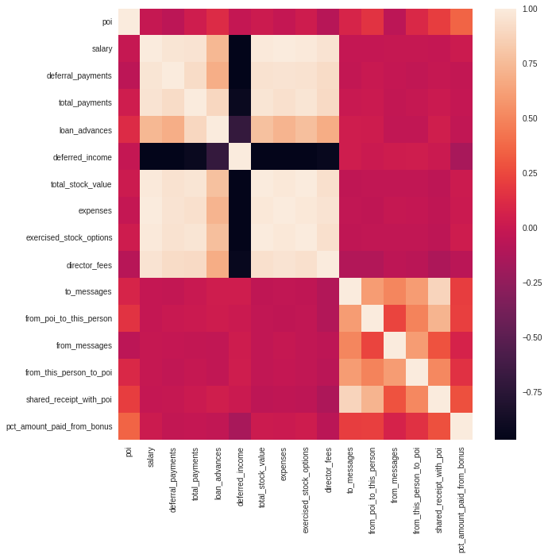

```python
## corelation in filtered features
plt.figure(figsize=(10, 10))
sns.heatmap(my_data_selected.corr());
```

# Modeling experiments

1. Take the selected features from data as and find the best/highly accurate model.

```python
my_data_selected
```

|  | poi | salary | deferral_payments | total_payments | loan_advances | deferred_income | total_stock_value | expenses | exercised_stock_options | director_fees | to_messages | from_poi_to_this_person | from_messages | from_this_person_to_poi | shared_receipt_with_poi | pct_amount_paid_from_bonus |
| --- | --- | --- | --- | --- | --- | --- | --- | --- | --- | --- | --- | --- | --- | --- | --- | --- |
| 0 | 0.0 | 201955.0 | 2869717.0 | 4484442.0 | 0.0 | -3081055.0 | 1729541.0 | 13868.0 | 1729541.0 | 0.0 | 2902.0 | 47.0 | 2195.0 | 65.0 | 1407.0 | 0.930997 |
| 1 | 0.0 | 0.0 | 178980.0 | 182466.0 | 0.0 | 0.0 | 257817.0 | 3486.0 | 257817.0 | 0.0 | 0.0 | 0.0 | 0.0 | 0.0 | 0.0 | 0.000000 |
| 2 | 0.0 | 477.0 | 0.0 | 916197.0 | 0.0 | -5104.0 | 5243487.0 | 56301.0 | 4046157.0 | 0.0 | 566.0 | 39.0 | 29.0 | 0.0 | 465.0 | 0.000000 |
| 3 | 0.0 | 267102.0 | 1295738.0 | 5634343.0 | 0.0 | -1386055.0 | 10623258.0 | 11200.0 | 6680544.0 | 0.0 | 0.0 | 0.0 | 0.0 | 0.0 | 0.0 | 0.212980 |
| 4 | 0.0 | 239671.0 | 260455.0 | 827696.0 | 0.0 | -201641.0 | 63014.0 | 129142.0 | 0.0 | 0.0 | 0.0 | 0.0 | 0.0 | 0.0 | 0.0 | 0.483269 |
| ... | ... | ... | ... | ... | ... | ... | ... | ... | ... | ... | ... | ... | ... | ... | ... | ... |
| 108 | 0.0 | 63744.0 | 0.0 | 762135.0 | 0.0 | -10800.0 | 384930.0 | 51870.0 | 0.0 | 0.0 | 0.0 | 0.0 | 0.0 | 0.0 | 0.0 | 0.000000 |
| 109 | 0.0 | 510364.0 | 0.0 | 4677574.0 | 0.0 | 0.0 | 6079137.0 | 57838.0 | 3282960.0 | 0.0 | 6019.0 | 186.0 | 556.0 | 24.0 | 3920.0 | 0.641358 |
| 110 | 0.0 | 317543.0 | 0.0 | 1934359.0 | 0.0 | 0.0 | 15144123.0 | 81353.0 | 1297049.0 | 0.0 | 0.0 | 0.0 | 0.0 | 0.0 | 0.0 | 0.232635 |
| 111 | 0.0 | 0.0 | 0.0 | 84992.0 | 0.0 | -25000.0 | 0.0 | 1413.0 | 0.0 | 108579.0 | 0.0 | 0.0 | 0.0 | 0.0 | 0.0 | 0.000000 |
| 112 | 1.0 | 158403.0 | 0.0 | 360300.0 | 0.0 | 0.0 | 11884758.0 | 53947.0 | 8308552.0 | 0.0 | 0.0 | 0.0 | 0.0 | 0.0 | 0.0 | 0.000000 |

113 rows × 16 columns

```python
experiment = setup(my_data_selected, target='poi')
best_model = compare_models(sort='F1')
```

|  | Model | Accuracy | AUC | Recall | Prec. | F1 | Kappa | MCC | TT (Sec) |
| --- | --- | --- | --- | --- | --- | --- | --- | --- | --- |
| lightgbm | Light Gradient Boosting Machine | 0.9000 | 0.7905 | 0.45 | 0.5000 | 0.4667 | 0.4457 | 0.4512 | 0.023 |
| ada | Ada Boost Classifier | 0.8375 | 0.6994 | 0.35 | 0.4000 | 0.3667 | 0.2914 | 0.2933 | 0.092 |
| gbc | Gradient Boosting Classifier | 0.8125 | 0.6786 | 0.35 | 0.3250 | 0.3067 | 0.2364 | 0.2529 | 0.065 |
| nb | Naive Bayes | 0.3161 | 0.4542 | 0.95 | 0.1739 | 0.2893 | 0.0494 | 0.1394 | 0.015 |
| dt | Decision Tree Classifier | 0.7357 | 0.5798 | 0.35 | 0.2333 | 0.2667 | 0.1390 | 0.1452 | 0.016 |
| rf | Random Forest Classifier | 0.8625 | 0.6875 | 0.25 | 0.3000 | 0.2667 | 0.2314 | 0.2369 | 0.467 |
| lda | Linear Discriminant Analysis | 0.8232 | 0.7274 | 0.30 | 0.2500 | 0.2667 | 0.2029 | 0.2083 | 0.015 |
| ridge | Ridge Classifier | 0.8357 | 0.0000 | 0.20 | 0.2000 | 0.2000 | 0.1571 | 0.1571 | 0.014 |
| svm | SVM - Linear Kernel | 0.7214 | 0.0000 | 0.25 | 0.1750 | 0.1900 | 0.0624 | 0.0587 | 0.016 |
| et | Extra Trees Classifier | 0.8482 | 0.7125 | 0.20 | 0.1500 | 0.1667 | 0.1457 | 0.1512 | 0.486 |
| lr | Logistic Regression | 0.7357 | 0.6893 | 0.20 | 0.0750 | 0.1067 | -0.0066 | 0.0018 | 0.033 |
| qda | Quadratic Discriminant Analysis | 0.5839 | 0.5405 | 0.20 | 0.0476 | 0.0750 | -0.1066 | -0.1145 | 0.015 |
| knn | K Neighbors Classifier | 0.7982 | 0.6560 | 0.00 | 0.0000 | 0.0000 | -0.0629 | -0.0647 | 0.117 |
| dummy | Dummy Classifier | 0.8482 | 0.5000 | 0.00 | 0.0000 | 0.0000 | 0.0000 | 0.0000 | 0.012 |

```python
best_model
```

```
LGBMClassifier(boosting_type='gbdt', class_weight=None, colsample_bytree=1.0,
               importance_type='split', learning_rate=0.1, max_depth=-1,
               min_child_samples=20, min_child_weight=0.001, min_split_gain=0.0,
               n_estimators=100, n_jobs=-1, num_leaves=31, objective=None,
               random_state=6049, reg_alpha=0.0, reg_lambda=0.0, silent='warn',
               subsample=1.0, subsample_for_bin=200000, subsample_freq=0)
```

```python
from sklearn.ensemble import AdaBoostClassifier
from sklearn.preprocessing import MinMaxScaler
from sklearn.model_selection import train_test_split
from sklearn.metrics import precision_score, recall_score
```

```python
scaller = MinMaxScaler()

best_model = AdaBoostClassifier()
```

#### Model training and evaluation

```python
### testing the best model with tester code
### splitting the selected data into X(features-independent vars) and y (labels-dependent vars)
labels, features = targetFeatureSplit(my_data_selected.values)

### ### scalling the data
features_scalled  = scaller.fit_transform(features)


### split the data in train and test
X_train, X_test, y_train, y_test = train_test_split(features_scalled, labels, test_size=0.2, random_state=42)
```

```python
### train the model
best_model.fit(X_train, y_train)
```

```
AdaBoostClassifier()
```

```python
### evaluate the model on testing data
### accuracy
preds = best_model.predict(X_test)

acc = best_model.score(X_test, y_test)
print('Accuracy=', acc)

prec = precision_score(y_test, preds)
print('Precision=', prec)

recall = recall_score(y_test, preds)
print('Recall=', recall)
```

```
Accuracy= 0.782608695652174
Precision= 0.2857142857142857
Recall= 1.0
```

```python
my_data_selected.columns
```

```
Index(['poi', 'salary', 'deferral_payments', 'total_payments', 'loan_advances',
       'deferred_income', 'total_stock_value', 'expenses',
       'exercised_stock_options', 'director_fees', 'to_messages',
       'from_poi_to_this_person', 'from_messages', 'from_this_person_to_poi',
       'shared_receipt_with_poi', 'pct_amount_paid_from_bonus'],
      dtype='object')
```

```python
### Task 5: Tune your classifier to achieve better than .3 precision and recall
### using our testing script. Check the tester.py script in the final project
### folder for details on the evaluation method, especially the test_classifier
### function. Because of the small size of the dataset, the script uses
### stratified shuffle split cross validation. For more info:
### http://scikit-learn.org/stable/modules/generated/sklearn.cross_validation.StratifiedShuffleSplit.html


precision, recall, accuracy = test_classifier(best_model, my_data_selected, folds=500)
print(f'Precision: {precision}')
print(f'Recall: {recall}')
print(f'Accuracy: {accuracy}')
print()
```

```
Precision: 0.3700873362445415
Recall: 0.339
Accuracy: 0.7936666666666666
```

### Tuning using the gridsearch cv

```python
from sklearn.model_selection import GridSearchCV
```

```python
best_model = AdaBoostClassifier(random_state=8895)
```

```python
params = {
    'base_estimator': [None],
    'learning_rate' : [0.1, 1.0, 0.01],
    'n_estimators': [20, 50, 100, 150],
    'algorithm': ['SAMME', 'SAMME.R']

}
```

```python
grid_cv = GridSearchCV(best_model, params, scoring='f1', verbose=1)
```

```python
grid_cv.fit(features_scalled, labels)
```

```
Fitting 5 folds for each of 24 candidates, totalling 120 fits
```

```
[Parallel(n_jobs=1)]: Using backend SequentialBackend with 1 concurrent workers.
[Parallel(n_jobs=1)]: Done 120 out of 120 | elapsed:   28.9s finished
```

```
GridSearchCV(estimator=AdaBoostClassifier(random_state=8895),
             param_grid={'algorithm': ['SAMME', 'SAMME.R'],
                         'base_estimator': [None],
                         'learning_rate': [0.1, 1.0, 0.01],
                         'n_estimators': [20, 50, 100, 150]},
             scoring='f1', verbose=1)
```

```python
grid_cv.best_params_
```

[output not shown]

```python
best_model = AdaBoostClassifier(algorithm='SAMME.R', base_estimator=None, learning_rate=1.0,
                   n_estimators=50, random_state=8895)
```

```python
best_model
```

```
AdaBoostClassifier(random_state=8895)
```

```python
### train the model
best_model.fit(X_train, y_train)
```

```
AdaBoostClassifier(random_state=8895)
```

```python
X_train.shape
```

```
(90, 15)
```

```python
highly_corr_feats
```

```
['poi',
 'salary',
 'deferral_payments',
 'total_payments',
 'loan_advances',
 'deferred_income',
 'total_stock_value',
 'expenses',
 'exercised_stock_options',
 'director_fees',
 'to_messages',
 'from_poi_to_this_person',
 'from_messages',
 'from_this_person_to_poi',
 'shared_receipt_with_poi',
 'pct_amount_paid_from_bonus']
```

```python
### find feature importance from model
best_model.feature_importances_
```

```
array([0.1 , 0.02, 0.04, 0.  , 0.04, 0.18, 0.14, 0.14, 0.  , 0.02, 0.04,
       0.04, 0.1 , 0.06, 0.08])
```

```python
feature_scores = pd.DataFrame((highly_corr_feats[1:], best_model.feature_importances_))
```

```python
feature_scores.transpose()
```

|  | 0 | 1 |
| --- | --- | --- |
| 0 | salary | 0.1 |
| 1 | deferral_payments | 0.02 |
| 2 | total_payments | 0.04 |
| 3 | loan_advances | 0.0 |
| 4 | deferred_income | 0.04 |
| 5 | total_stock_value | 0.18 |
| 6 | expenses | 0.14 |
| 7 | exercised_stock_options | 0.14 |
| 8 | director_fees | 0.0 |
| 9 | to_messages | 0.02 |
| 10 | from_poi_to_this_person | 0.04 |
| 11 | from_messages | 0.04 |
| 12 | from_this_person_to_poi | 0.1 |
| 13 | shared_receipt_with_poi | 0.06 |
| 14 | pct_amount_paid_from_bonus | 0.08 |

```python
#### saving the classifier
dump_classifier_and_data(best_model, my_dataset, features_list)
```